# Final

## An Analysis of Air Quality Data and Related Statistics

By Kenny Ha

### Introduction

Air pollution is a significant environmental problem that affects the health and well-being of millions of people worldwide. Poor air quality has been linked to various health issues, including respiratory and cardiovascular diseases, as well as developmental and neurological problems. With the growing concern over the impact of air pollution on public health and safety, there has been an increasing interest in understanding the relationship between air quality and various related subjects, such as climate change, energy use, and transportation.

Using the data science pipeline, we analyze air quality data from multiple sources to draw conclusions about the impact of air pollution on human health and safety, as well as explore potential solutions to mitigate the negative effects of air pollution. By examining the trends in air quality over time and across different regions, I hope to provide insights that can inform and promote a cleaner and healthier environment for all.

The data science pipeline includes the following:

1. Data Collection
2. Data Processing/Management
3. Exploratory Data Analysis
4. Hypothesis Testing
5. Conclusion

### Data Collection

We will start by gathering the data that is relevant for our topic. In this case, we are looking for a dataset that contains information about the pollution levels across a number of years in a specific area. We also have to ensure the data collected is up to date and legitimate. To this end, the US government has a catalogue of data in which we can find our source: https://catalog.data.gov/dataset/air-quality. This is a dataset perfect for our purpose; New York City air quality surveillance data. The site includes a download of a .csv of the dataset, giving us direct access to the information.

We also need information about the health of the population during these years so we can actually find out ourselves if there is a correlation between health and air quality and how strong it might be. Our first dataset does have data for this, but in case we need additional data, the US government also has a dataset that gives us information on 21 selected chronic conditions among original medicare beneficiaries, of which includes ailments such as asthma, lung cancer, and heart failure, among others: https://catalog.data.gov/dataset/specific-chronic-conditions-0f448. While this dataset covers other states, we can separate out just the relevant information later during our data processing step.

We will be using Python to analyze the data. We will need to import relevant libraries for this purpose. We also need to import the actual .csv files containing the data we need. Below is the code that completes these tasks.

```python
import numpy as np
import pandas as pd
import seaborn as sb
import matplotlib.pyplot as plt
from datetime import datetime, timedelta
from sklearn.linear_model import LinearRegression
import statsmodels.formula.api as sm

df = pd.read_csv(r'Air_Quality.csv')
df2007 = pd.read_csv(r'2007.csv')
df2008 = pd.read_csv(r'2008.csv')
df2009 = pd.read_csv(r'2009.csv')
df2010 = pd.read_csv(r'2010.csv')
df2011 = pd.read_csv(r'2011.csv')
df2012 = pd.read_csv(r'2012.csv')
df2013 = pd.read_csv(r'2013.csv')
df2014 = pd.read_csv(r'2014.csv')
df2015 = pd.read_csv(r'2015.csv')
df2016 = pd.read_csv(r'2016.csv')
df2017 = pd.read_csv(r'2017.csv')
df2018 = pd.read_csv(r'2018.csv')
```

Luckily for us, the data we collected is fairly neatly organized within the .csv files. When we import the csv, it is already in table form with labels, making this portion much simpler. However, because the data for health is separated by year, we have to read each .csv for the health data individually. Eventually they can be consolidated so just the info we need is used, but for now we need all the files. As it stands, we can see the results of our data collections below:

```python
df.head()
```

|  | Unique ID | Indicator ID | Name | Measure | Measure Info | Geo Type Name | Geo Join ID | Geo Place Name | Time Period | Start_Date | Data Value | Message |
| --- | --- | --- | --- | --- | --- | --- | --- | --- | --- | --- | --- | --- |
| 0 | 216498 | 386 | Ozone (O3) | Mean | ppb | CD | 313 | Coney Island (CD13) | Summer 2013 | 06/01/2013 | 34.64 | NaN |
| 1 | 216499 | 386 | Ozone (O3) | Mean | ppb | CD | 313 | Coney Island (CD13) | Summer 2014 | 06/01/2014 | 33.22 | NaN |
| 2 | 219969 | 386 | Ozone (O3) | Mean | ppb | Borough | 1 | Bronx | Summer 2013 | 06/01/2013 | 31.25 | NaN |
| 3 | 219970 | 386 | Ozone (O3) | Mean | ppb | Borough | 1 | Bronx | Summer 2014 | 06/01/2014 | 31.15 | NaN |
| 4 | 164876 | 383 | Sulfur Dioxide (SO2) | Mean | ppb | CD | 211 | Morris Park and Bronxdale (CD11) | Winter 2008-09 | 12/01/2008 | 5.89 | NaN |

As we can see, the value for air quality is given by 'Data Value', but each data point is split by many different factors, including what was being measured in the air, what the time period was, and where the data was recorded.

```python
df2007.head()
```

|  | Bene_Geo_Lvl | Bene_Geo_Desc | Bene_Geo_Cd | Bene_Age_Lvl | Bene_Demo_Lvl | Bene_Demo_Desc | Bene_Cond | Prvlnc | Tot_Mdcr_Stdzd_Pymt_PC | Tot_Mdcr_Pymt_PC | Hosp_Readmsn_Rate | ER_Visits_Per_1000_Benes |
| --- | --- | --- | --- | --- | --- | --- | --- | --- | --- | --- | --- | --- |
| 0 | State | Alabama | 1.0 | All | All | All | Alcohol Abuse | 0.0135 | 20671.5781 | 19615.612 | 0.2532 | 2298.6431 |
| 1 | State | Alabama | 1.0 | 65+ | Dual Status | Medicare Only | Alcohol Abuse | 0.0066 | NaN | NaN | NaN | NaN |
| 2 | State | Alabama | 1.0 | <65 | Dual Status | Medicare Only | Alcohol Abuse | 0.0257 | NaN | NaN | NaN | NaN |
| 3 | State | Alabama | 1.0 | All | Dual Status | Medicare Only | Alcohol Abuse | 0.0097 | NaN | NaN | NaN | NaN |
| 4 | State | Alabama | 1.0 | 65+ | Dual Status | Medicare and Medicaid | Alcohol Abuse | 0.0145 | NaN | NaN | NaN | NaN |

As we can see above, the csv's for health are already separated by year so the table is instead separated by state and ailment, among other things. One thing to note is that each state and ailment combination has a row dedicated to the number of readmissions to the hospital and ER visits made by patients within that state with that ailment. This means we can compare states against one another and see if certain states have a higher proportion of visits than the other for certain illnesses.

### Data Processing/Management

Now that we have our data, we need to consolidate it into a usable form. Currently, the data is stuck in a table, with some rows being irrelevant, and some info we need is stuck within these rows.

```python
df2007 = df2007.loc[df2007['ER_Visits_Per_1000_Benes'] > 0].sort_values('Bene_Cond').loc[df2007['Bene_Geo_Desc'] == "New York"].drop('Bene_Age_Lvl',axis=1).drop('Bene_Demo_Lvl',axis=1).drop('Bene_Demo_Desc',axis=1)
df2008 = df2008.loc[df2008['ER_Visits_Per_1000_Benes'] > 0].sort_values('Bene_Cond').loc[df2008['Bene_Geo_Desc'] == "New York"].drop('Bene_Age_Lvl',axis=1).drop('Bene_Demo_Lvl',axis=1).drop('Bene_Demo_Desc',axis=1)
df2009 = df2009.loc[df2009['ER_Visits_Per_1000_Benes'] > 0].sort_values('Bene_Cond').loc[df2009['Bene_Geo_Desc'] == "New York"].drop('Bene_Age_Lvl',axis=1).drop('Bene_Demo_Lvl',axis=1).drop('Bene_Demo_Desc',axis=1)
df2010 = df2010.loc[df2010['ER_Visits_Per_1000_Benes'] > 0].sort_values('Bene_Cond').loc[df2010['Bene_Geo_Desc'] == "New York"].drop('Bene_Age_Lvl',axis=1).drop('Bene_Demo_Lvl',axis=1).drop('Bene_Demo_Desc',axis=1)
df2011 = df2011.loc[df2011['ER_Visits_Per_1000_Benes'] > 0].sort_values('Bene_Cond').loc[df2011['Bene_Geo_Desc'] == "New York"].drop('Bene_Age_Lvl',axis=1).drop('Bene_Demo_Lvl',axis=1).drop('Bene_Demo_Desc',axis=1)
df2012 = df2012.loc[df2012['ER_Visits_Per_1000_Benes'] > 0].sort_values('Bene_Cond').loc[df2012['Bene_Geo_Desc'] == "New York"].drop('Bene_Age_Lvl',axis=1).drop('Bene_Demo_Lvl',axis=1).drop('Bene_Demo_Desc',axis=1)
df2013 = df2013.loc[df2013['ER_Visits_Per_1000_Benes'] > 0].sort_values('Bene_Cond').loc[df2013['Bene_Geo_Desc'] == "New York"].drop('Bene_Age_Lvl',axis=1).drop('Bene_Demo_Lvl',axis=1).drop('Bene_Demo_Desc',axis=1)
df2014 = df2014.loc[df2014['ER_Visits_Per_1000_Benes'] > 0].sort_values('Bene_Cond').loc[df2014['Bene_Geo_Desc'] == "New York"].drop('Bene_Age_Lvl',axis=1).drop('Bene_Demo_Lvl',axis=1).drop('Bene_Demo_Desc',axis=1)
df2015 = df2015.loc[df2015['ER_Visits_Per_1000_Benes'] > 0].sort_values('Bene_Cond').loc[df2015['Bene_Geo_Desc'] == "New York"].drop('Bene_Age_Lvl',axis=1).drop('Bene_Demo_Lvl',axis=1).drop('Bene_Demo_Desc',axis=1)
df2016 = df2016.loc[df2016['ER_Visits_Per_1000_Benes'] > 0].sort_values('Bene_Cond').loc[df2016['Bene_Geo_Desc'] == "New York"].drop('Bene_Age_Lvl',axis=1).drop('Bene_Demo_Lvl',axis=1).drop('Bene_Demo_Desc',axis=1)
df2017 = df2017.loc[df2017['ER_Visits_Per_1000_Benes'] > 0].sort_values('Bene_Cond').loc[df2017['Bene_Geo_Desc'] == "New York"].drop('Bene_Age_Lvl',axis=1).drop('Bene_Demo_Lvl',axis=1).drop('Bene_Demo_Desc',axis=1)
df2018 = df2018.loc[df2018['ER_Visits_Per_1000_Benes'] > 0].sort_values('Bene_Cond').loc[df2018['Bene_Geo_Desc'] == "New York"].drop('Bene_Age_Lvl',axis=1).drop('Bene_Demo_Lvl',axis=1).drop('Bene_Demo_Desc',axis=1)
df2007
```

|  | Bene_Geo_Lvl | Bene_Geo_Desc | Bene_Geo_Cd | Bene_Cond | Prvlnc | Tot_Mdcr_Stdzd_Pymt_PC | Tot_Mdcr_Pymt_PC | Hosp_Readmsn_Rate | ER_Visits_Per_1000_Benes |
| --- | --- | --- | --- | --- | --- | --- | --- | --- | --- |
| 9009 | State | New York | 36.0 | Alcohol Abuse | 0.0159 | 18562.5626 | 23699.4573 | 0.2965 | 2058.3508 |
| 9022 | State | New York | 36.0 | Alzheimer's Disease/Dementia | 0.1183 | 16738.3125 | 21317.7556 | 0.2614 | 1166.8699 |
| 9035 | State | New York | 36.0 | Arthritis | 0.2709 | 11769.2157 | 14260.1787 | 0.2050 | 734.2547 |
| 9048 | State | New York | 36.0 | Asthma | 0.0495 | 16570.6255 | 21083.9618 | 0.2678 | 1416.1295 |
| 9061 | State | New York | 36.0 | Atrial Fibrillation | 0.0839 | 19541.1513 | 24295.9812 | 0.2655 | 1182.5989 |
| 9074 | State | New York | 36.0 | Autism Spectrum Disorders | 0.0015 | 5196.9220 | 6174.1029 | 0.2125 | 908.6587 |
| 9087 | State | New York | 36.0 | COPD | 0.1090 | 19954.9588 | 24524.5827 | 0.2773 | 1378.2924 |
| 9100 | State | New York | 36.0 | Cancer | 0.0868 | 15858.4080 | 19104.1270 | 0.2270 | 772.0031 |
| 9113 | State | New York | 36.0 | Chronic Kidney Disease | 0.1171 | 24357.8912 | 30627.3272 | 0.2991 | 1361.0997 |
| 9126 | State | New York | 36.0 | Depression | 0.1186 | 16430.5465 | 19836.5618 | 0.2591 | 1310.8746 |
| 9139 | State | New York | 36.0 | Diabetes | 0.2848 | 12541.5149 | 15557.6676 | 0.2452 | 777.6757 |
| 9152 | State | New York | 36.0 | Drug/Substance Abuse | 0.0116 | 20955.6511 | 26350.3275 | 0.3387 | 2764.1679 |
| 9165 | State | New York | 36.0 | HIV/AIDS | 0.0063 | 14827.4174 | 20455.9989 | 0.3216 | 1243.9105 |
| 9178 | State | New York | 36.0 | Heart Failure | 0.1934 | 19520.2334 | 24702.2770 | 0.2698 | 1183.4505 |
| 9191 | State | New York | 36.0 | Hepatitis (Chronic Viral B & C) | 0.0075 | 21279.5937 | 28843.8143 | 0.3549 | 1730.9245 |
| 9204 | State | New York | 36.0 | Hyperlipidemia | 0.4502 | 9607.1914 | 11631.2920 | 0.2018 | 606.0595 |
| 9217 | State | New York | 36.0 | Hypertension | 0.5623 | 11170.5364 | 13687.1812 | 0.2171 | 728.9081 |
| 9230 | State | New York | 36.0 | Ischemic Heart Disease | 0.3744 | 13754.8677 | 17137.7991 | 0.2343 | 856.7181 |
| 9243 | State | New York | 36.0 | Osteoporosis | 0.0717 | 12532.1579 | 15120.5464 | 0.2030 | 814.6345 |
| 9256 | State | New York | 36.0 | Schizophrenia and Other Psychotic Disorders | 0.0418 | 17050.0196 | 21099.0428 | 0.2942 | 1548.9266 |
| 9269 | State | New York | 36.0 | Stroke | 0.0453 | 24422.7149 | 31360.1393 | 0.2692 | 1589.4835 |

The above code removes all the unneccessary rows for all the health data sets for all the years. The remaining data are the health totals for New York for each ailment. Instead of having all the individual information, we can now see the relevant information much more clearly. (The state will always be New York, but the column was kept so we can be sure that the data was sorted properly.) All 21 ailments are present, and only the rows containing the ailment data totals were kept, removing the unneccessary clutter. However, we still need to combine the data so that it is all in one table. Having them all separated makes it difficult to use.

```python
df2007['Year'] = 2007
df2008['Year'] = 2008
df2009['Year'] = 2009
df2010['Year'] = 2010
df2011['Year'] = 2011
df2012['Year'] = 2012
df2013['Year'] = 2013
df2014['Year'] = 2014
df2015['Year'] = 2015
df2016['Year'] = 2016
df2017['Year'] = 2017
df2018['Year'] = 2018
df2 = pd.concat([df2007,df2008,df2009,df2010,df2011,df2012,df2013,df2014,df2015,df2016,df2017,df2018])
df2.head()
```

|  | Bene_Geo_Lvl | Bene_Geo_Desc | Bene_Geo_Cd | Bene_Cond | Prvlnc | Tot_Mdcr_Stdzd_Pymt_PC | Tot_Mdcr_Pymt_PC | Hosp_Readmsn_Rate | ER_Visits_Per_1000_Benes | Year |
| --- | --- | --- | --- | --- | --- | --- | --- | --- | --- | --- |
| 9009 | State | New York | 36.0 | Alcohol Abuse | 0.0159 | 18562.5626 | 23699.4573 | 0.2965 | 2058.3508 | 2007 |
| 9022 | State | New York | 36.0 | Alzheimer's Disease/Dementia | 0.1183 | 16738.3125 | 21317.7556 | 0.2614 | 1166.8699 | 2007 |
| 9035 | State | New York | 36.0 | Arthritis | 0.2709 | 11769.2157 | 14260.1787 | 0.2050 | 734.2547 | 2007 |
| 9048 | State | New York | 36.0 | Asthma | 0.0495 | 16570.6255 | 21083.9618 | 0.2678 | 1416.1295 | 2007 |
| 9061 | State | New York | 36.0 | Atrial Fibrillation | 0.0839 | 19541.1513 | 24295.9812 | 0.2655 | 1182.5989 | 2007 |

With this code, we have added a column telling us what year the data was from, and then we concatenated all of the tables into one table. Now it is in a usable form.

Next, we still need to sort the air quality data. This data is more difficult since the date format must be changed into a form that is readable by Python, which means we need use the datetime module, and there are also many different locations which break up the data even further. We need to first change the dates into a readable form:

```python
for i,j in df.iterrows():
  date = datetime.strptime(j['Start_Date'],"%m/%d/%Y").date()
  df.loc[i,'Start_Date'] = date.year

df = df.sort_values(['Name', 'Start_Date', 'Geo Place Name'])
df.head(5)
```

|  | Unique ID | Indicator ID | Name | Measure | Measure Info | Geo Type Name | Geo Join ID | Geo Place Name | Time Period | Start_Date | Data Value | Message |
| --- | --- | --- | --- | --- | --- | --- | --- | --- | --- | --- | --- | --- |
| 241 | 130716 | 646 | Air Toxics Concentrations- Average Benzene Con... | Annual Average Concentration | µg/m3 | UHF42 | 404 | Bayside - Little Neck | 2005 | 2005 | 1.9 | NaN |
| 219 | 130694 | 646 | Air Toxics Concentrations- Average Benzene Con... | Annual Average Concentration | µg/m3 | UHF42 | 203 | Bedford Stuyvesant - Crown Heights | 2005 | 2005 | 2.5 | NaN |
| 225 | 130700 | 646 | Air Toxics Concentrations- Average Benzene Con... | Annual Average Concentration | µg/m3 | UHF42 | 209 | Bensonhurst - Bay Ridge | 2005 | 2005 | 2.8 | NaN |
| 222 | 130697 | 646 | Air Toxics Concentrations- Average Benzene Con... | Annual Average Concentration | µg/m3 | UHF42 | 206 | Borough Park | 2005 | 2005 | 2.5 | NaN |
| 253 | 130728 | 646 | Air Toxics Concentrations- Average Benzene Con... | Annual Average Concentration | µg/m3 | Borough | 1 | Bronx | 2005 | 2005 | 2.8 | NaN |

### Data Analysis

Now that the data is in a usable form, we can begin creating visuals such as graphs to help us work towards our hypothesis. First we want to see any trends in the data by itself.

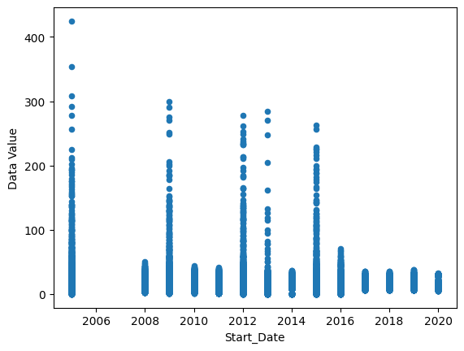

```python
df.plot(x='Start_Date',y='Data Value',kind='scatter')
```

We can see by the graph that in general, the measurements have trended down on average over the years. However, this is not very useful as the data values measure many different things; we need to choose one specific measurement type to single out at least for now. If we don't, the graph will be irrelevant as it will be comparing datapoint that measure Ozone to datapoints that measure Nitrogen, for example, and a change in value for Ozone could be counteracted by a change in value for Nitrogen in the opposite direction, and we woulnd't we able to tell with out current graph. As such, let us pick "Fine Particulate Matter (PM2.5)" for now, as this seems to be a measurement that could negatively impact health if the value is high enough.

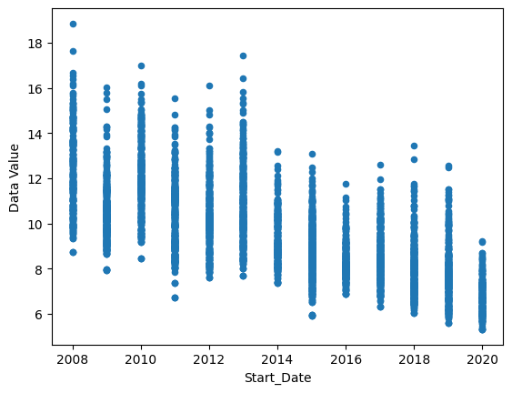

```python
df3 = df.loc[df['Name'] == "Fine Particulate Matter (PM2.5)"]
plot1 = df3.plot(x='Start_Date',y='Data Value',kind='scatter')
```

As we can see, the trend does hold even with this specific measurement. Over time, the average measurement of Fine Particulate Matter in the air decreases. Again, however, we cannot be certain that this is because the measurement itself is decreasing. We need to factor in location and ensure that the measurements are only from a certain location in case the data is missing the measurements from that location for some years which could skew the data.

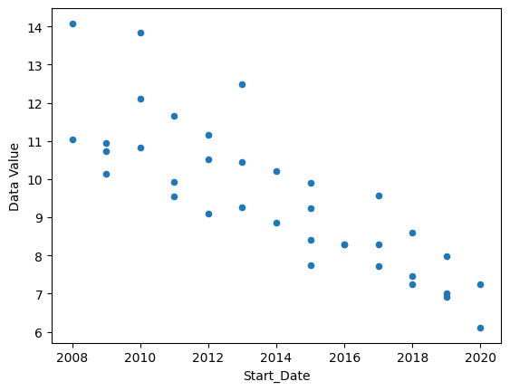

```python
df4 = df3.loc[df3['Geo Place Name'] == "Bronx"]
plot2 = df4.plot(x='Start_Date',y='Data Value',kind='scatter')
```

As we can see, it is certain to the best of our abilities now that the measurements are decreasing over time. Now we need to check the health data in a similar fashion. First let us take a look at the health data from the original dataset rather than the supplemental data.

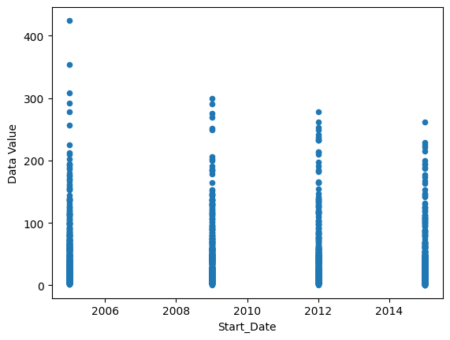

```python
df5 = df.loc[df['Name'].isin(["O3-Attributable Asthma Emergency Department Visits", "O3-Attributable Asthma Hospitalizations", "O3-Attributable Cardiac and Respiratory Deaths", "PM2.5-Attributable Asthma Emergency Department Visits", "PM2.5-Attributable Cardiovascular Hospitalizations (Adults 40 Yrs and Older)", "PM2.5-Attributable Deaths", "PM2.5-Attributable Respiratory Hospitalizations (Adults 20 Yrs and Older)"])]
df5.plot(x='Start_Date',y='Data Value',kind='scatter')
```

While the health data is not as complete as the air quality measurements, we can still see a general downward trend. The same cannot be said for the additional health data we collected.

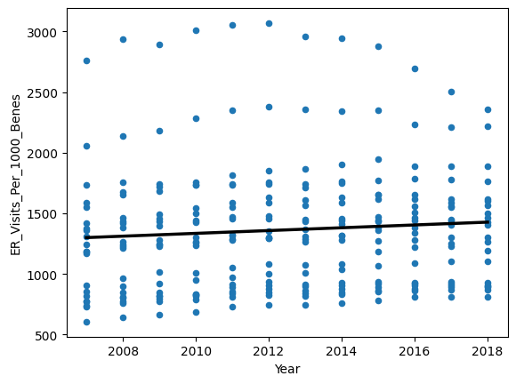

```python
df2.plot(x='Year',y='ER_Visits_Per_1000_Benes',kind='scatter')
b, a = np.polyfit(x=df2['Year'],y=df2['ER_Visits_Per_1000_Benes'],deg=1)
xseq = np.linspace(2007,2018,num=100)
plt.plot(xseq, a+b*xseq, color="k", lw=2.5)
```

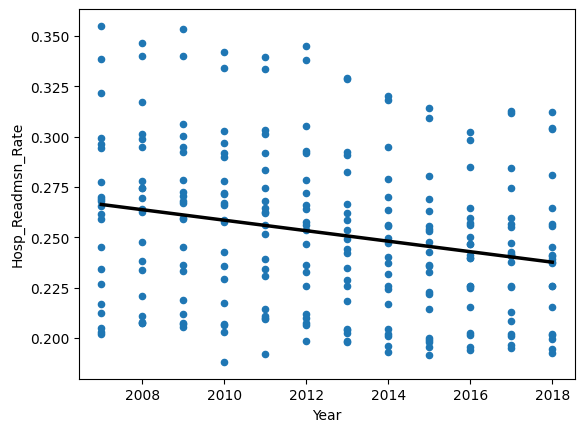

```python
df2.plot(x='Year',y='Hosp_Readmsn_Rate',kind='scatter')
b, a = np.polyfit(x=df2['Year'],y=df2['Hosp_Readmsn_Rate'],deg=1)
xseq = np.linspace(2007,2018,num=100)
plt.plot(xseq, a+b*xseq, color="k", lw=2.5)
```

The first graph shows the average number of emergency room visits per 1000 beneficiaries, while the second shows the hospital readmission rate for patients with the ailments. We can see that the average number of ER visits over all ailments seems to not change very much over time, whereas we can see that the average hospital readmission rate does seem to trend downwards.

With this, we can see that it is possible our additional health data could be unreliable for our purposes. It is possible that the health data is affected by many other factors which makes it unfit for our purposes. The health data that comes from the original air quality measurements, however, seem better suited for what we are looking for. The health data from there comes from the same locations instead of the entire state and measure ailments that were directly linked to air quality. With this is mind, we can begin our hypothesis testing.

### Hypothesis Testing

Now that we have our data collected and cleaned and have explored our data, we can posit our hypothesis that air quality is linked to health, and we can test this hypothesis through regression models.

```python
df.rename(columns = {'Data Value':'Data_Value'}, inplace = True)
statmodel = sm.ols(formula="Data_Value ~ Start_Date + Name ", data=df).fit()
print(statmodel.summary())
```

[output not shown]

[output cut: 22 more lines]

```
Name[T.PM2.5-Attributable Deaths]                                                       51.9036      2.150     24.142      0.000      47.689      56.118
Name[T.PM2.5-Attributable Respiratory Hospitalizations (Adults 20 Yrs and Older)]       17.6523      2.150      8.211      0.000      13.438      21.866
Name[T.Sulfur Dioxide (SO2)]                                                             8.3205      2.258      3.685      0.000       3.895      12.746
Name[T.Traffic Density- Annual Vehicle Miles Traveled]                                  27.9552      2.133     13.108      0.000      23.775      32.135
Name[T.Traffic Density- Annual Vehicle Miles Traveled for Cars]                         25.9822      2.123     12.240      0.000      21.822      30.143
Name[T.Traffic Density- Annual Vehicle Miles Traveled for Trucks]                       -0.6726      2.133     -0.315      0.752      -4.853       3.508
==============================================================================
Omnibus:                    19183.403   Durbin-Watson:                   0.850
Prob(Omnibus):                  0.000   Jarque-Bera (JB):          5190733.527
Skew:                           6.034   Prob(JB):                         0.00
Kurtosis:                      90.072   Cond. No.                         84.6
==============================================================================

Notes:
[1] Standard Errors assume that the covariance matrix of the errors is correctly specified.
```

This test is for seeing if there is a correlation between the data values and the year and type of measurement taken. If the values for P>|t| are near zero, it means for that time/measurement that we can reject the null hypothesis of there being no correlation between it and the data values measured. We can see by our p-values for the majortiy of the dates are near zero, so that means we can reject the null hypothesis for a majority of the dates.

We want to measure air quality against health, but there are a few problems with that in our data. Our measurements for each are not from the same exact area; one covers all of New York while the other is just of New York City. There is also the problem that the number of measurements for air quality are not the same as the number of measurements for health, which makes the program unable to calculate an accurate regression. Therefore, the above regression is one that we must use for now. Even still, we can see because there is a relationship between the year and the data value, and a relationship between the data value and the ailments, there is an indirect relationship.